# week4的功課

# 首先先將我們前幾個禮拜的Titanic資料夾打開，並將資料合併完整，因為我們發現裏頭資料有些不完整，所以我們要將test跟gender扣在一起，然後再把train跟first黏在一起。

```r
library(dplyr)
gender  <- read.csv('../week4/all/gender_submission.csv', stringsAsFactors = F)
test  <- read.csv('../week4/all/test.csv', stringsAsFactors = F)
train <- read.csv('../week4/all/train.csv', stringsAsFactors = F)
first <- merge(test, gender, by = "PassengerId")
full2 <- bind_rows(train, first)
```

# 然後將full2選取Survived並將其中的數值轉成factor形式。

```r
full2$Survived <- as.factor(full2$Survived)
```

# 接下來這個步驟我們是將活著的人所花的票錢，跟罹難的人的票錢各自做了盒鬚圖，我們可以從圖看出來，罹難的人的票錢跟存活的人的票錢實際上是有差距的。可以證實之前有一個說法是，因為票錢較貴的艙等，船艙會越上層，所以當水滲進船艙的時候，較低價位的船艙會先被水滲入。所以生存率比較低。

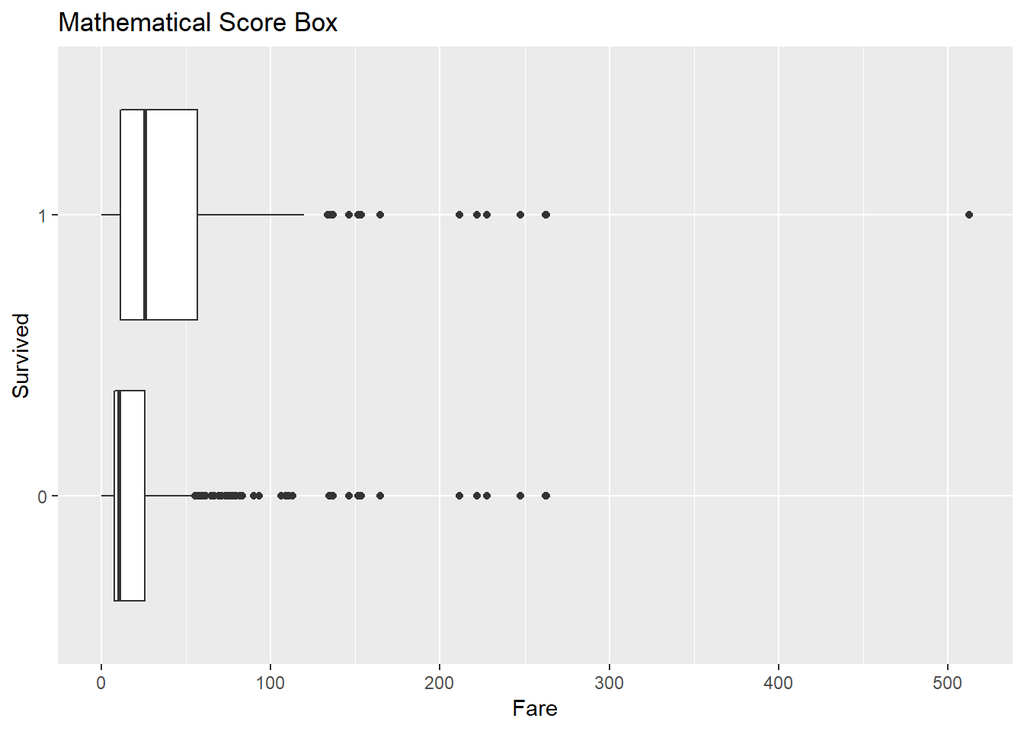

```r
library(ggplot2)
ggplot(data = full2, aes(x = Survived, y = Fare)) +
 geom_boxplot() + coord_flip() +
 labs( y = 'Fare', x = 'Survived',
       title = 'Mathematical Score Box')
```

# full3是我們用來削掉full2檔案中的Na。為的是要讓我們下面的函數可以繼續運行。

```r
full3<-na.omit(full2)
```

# 可以透過下面的函數看出來兩種狀況的人，他們的平均票價不一樣。

```r
#以下函式計算95%信賴區間
with(full3,
     tapply(Fare, Survived,
     function(x)
       c(mean(x) + c(-2, 2) * sd(x)/sqrt(length(x)))))
```

```
## $`0`
## [1] 22.86160 28.73623
##
## $`1`
## [1] 45.94848 60.21571
```

```r
t.test(Fare ~ Survived, data = full3)
```

```
##
##  Welch Two Sample t-test
##
## data:  Fare by Survived
## t = -7.0731, df = 558.37, p-value = 4.555e-12
## alternative hypothesis: true difference in means is not equal to 0
## 95 percent confidence interval:
##  -34.85985 -19.70651
## sample estimates:
## mean in group 0 mean in group 1
##        25.79892        53.08210
```

```r
t.test(Fare ~ Survived, data = full3, var.equal = TRUE)
```

```
##
##  Two Sample t-test
##
## data:  Fare by Survived
## t = -7.9787, df = 1043, p-value = 3.873e-15
## alternative hypothesis: true difference in means is not equal to 0
## 95 percent confidence interval:
##  -33.99306 -20.57330
## sample estimates:
## mean in group 0 mean in group 1
##        25.79892        53.08210
```

```r
library(Hmisc)
```

# 查看登陸地點跟票價關係

# Port of Embarkation C = Cherbourg, Q = Queenstown, S = Southampton

```r
full3$Embarked <- as.factor(full3$Embarked)
```

```r
#先把登陸地點定下來(order of factors)
full3$Embarked <- factor(full3$Embarked,
                       levels = c('C',
                                  'Q',
                                  'S'
                              ))

#然後看一下個地點他們的平均票價
tapply(full3$Fare, full3$Embarked, mean)
```

```
##        C        Q        S
## 72.47416 15.90592 28.19096
```